# Year 1 (2024)

##### Biomass (Chloroform fumigation method)

**click to open**

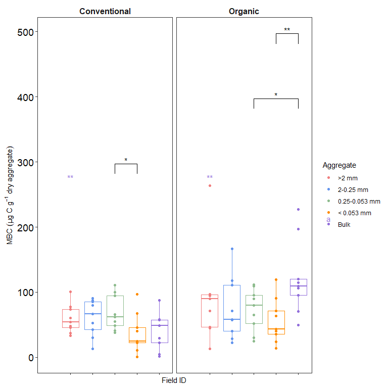

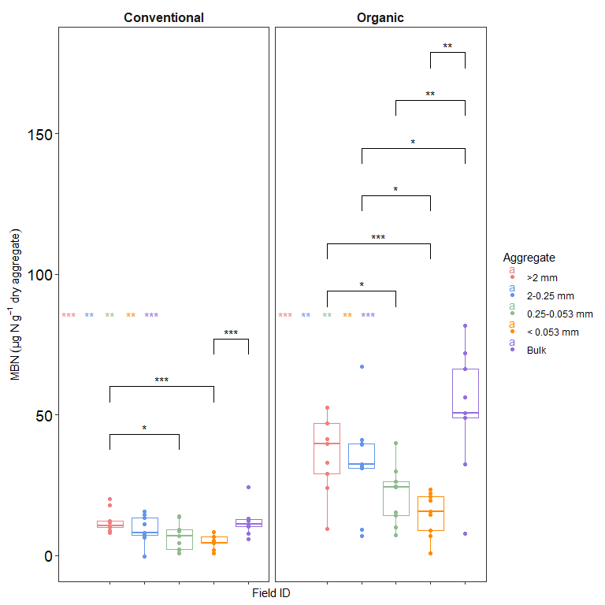

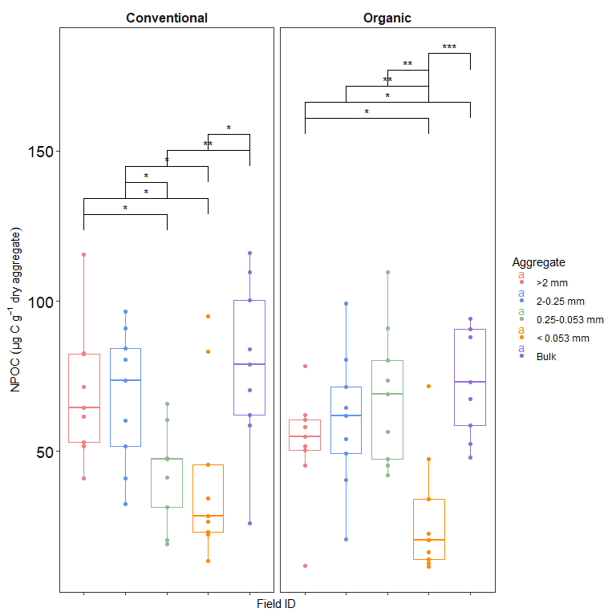

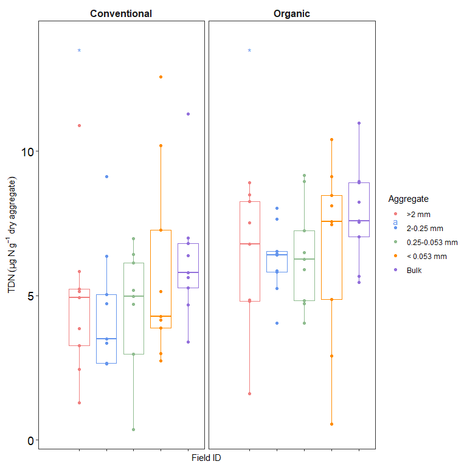

##### Enzymes activity (MUF and MC fluorimetic microplate assays)

**click to open**

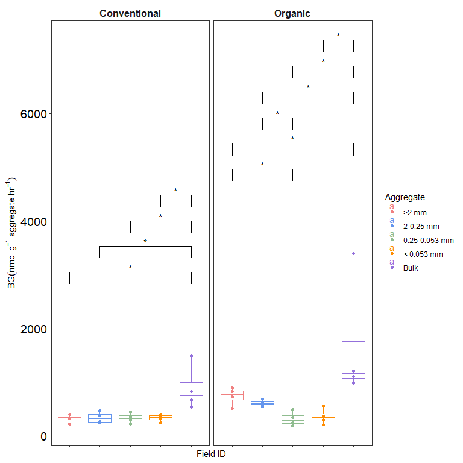

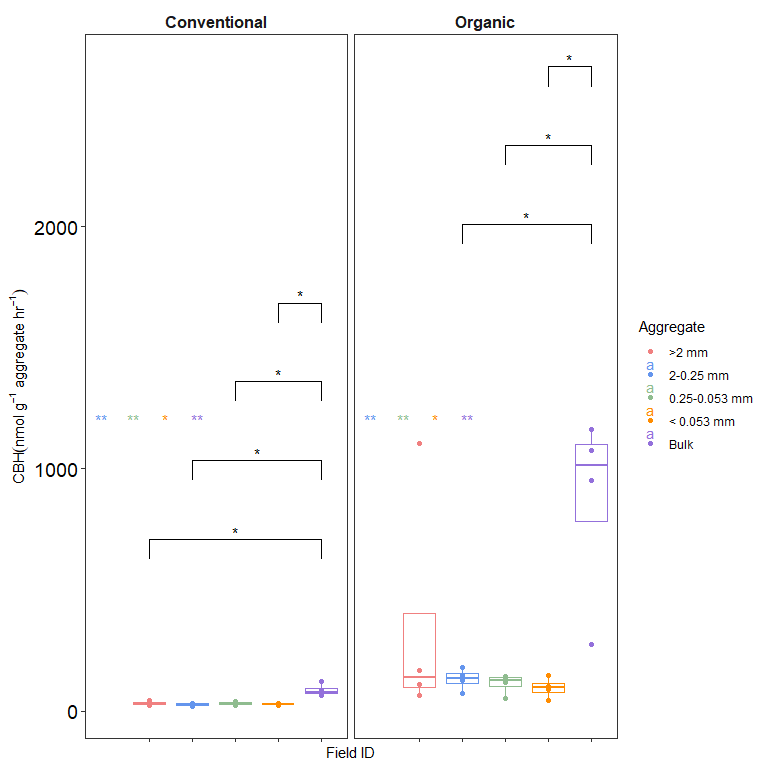

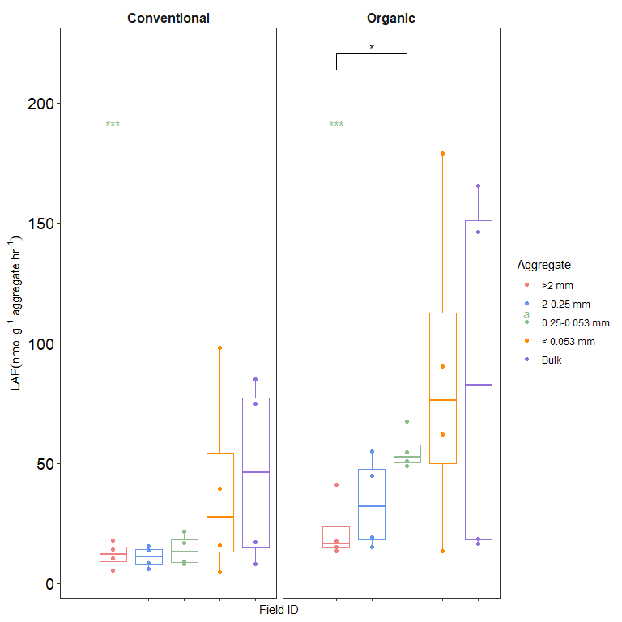

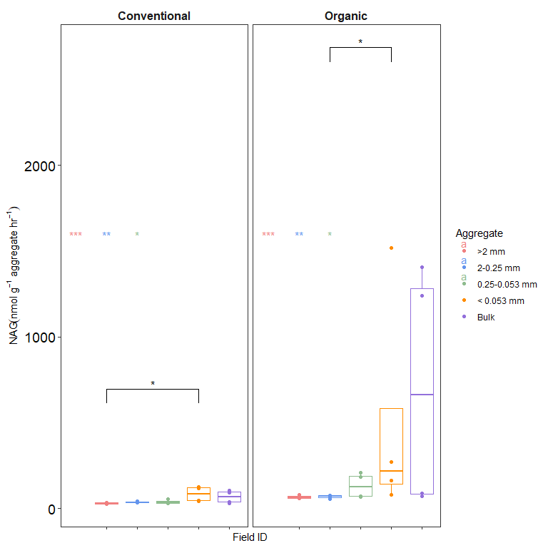

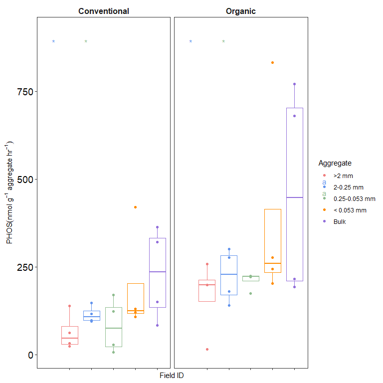

##### Fluorescein Diacetate Hydrolysis (FDA)

**click to open**

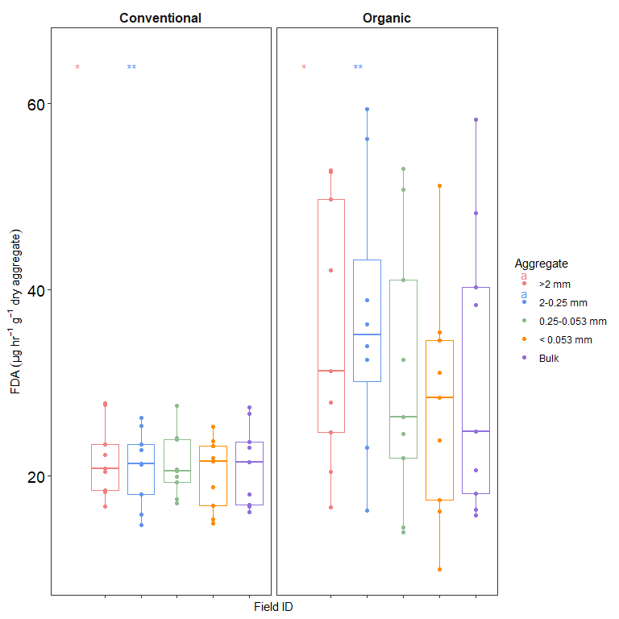

##### Permanganate-oxidizable carbon (POXC)

**click to open**

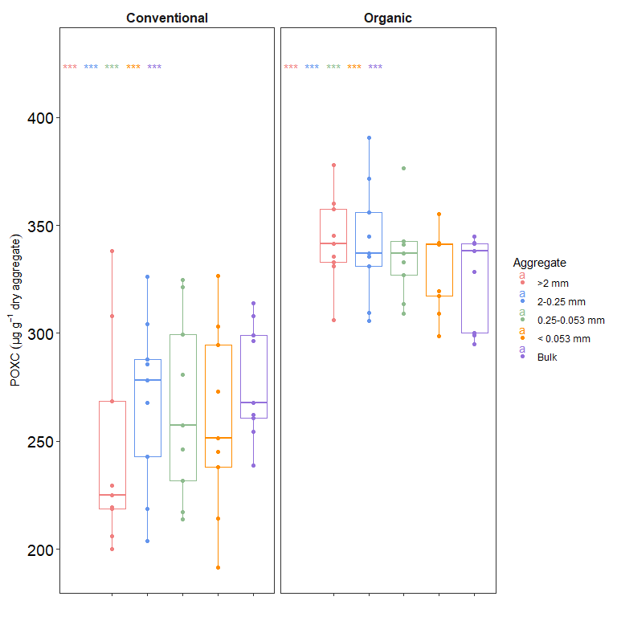

##### Carbon use efficency (CUE)

**click to open**

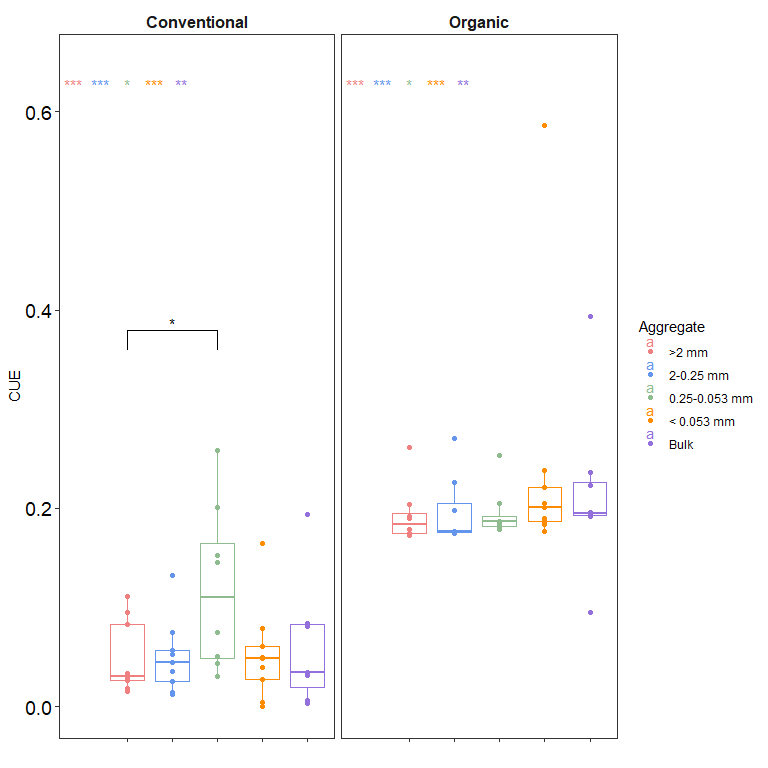

##### Mineral associated organic matter (MAOM)

**click to open**

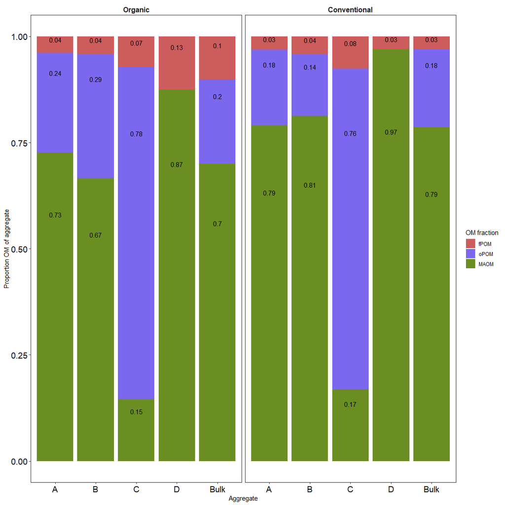

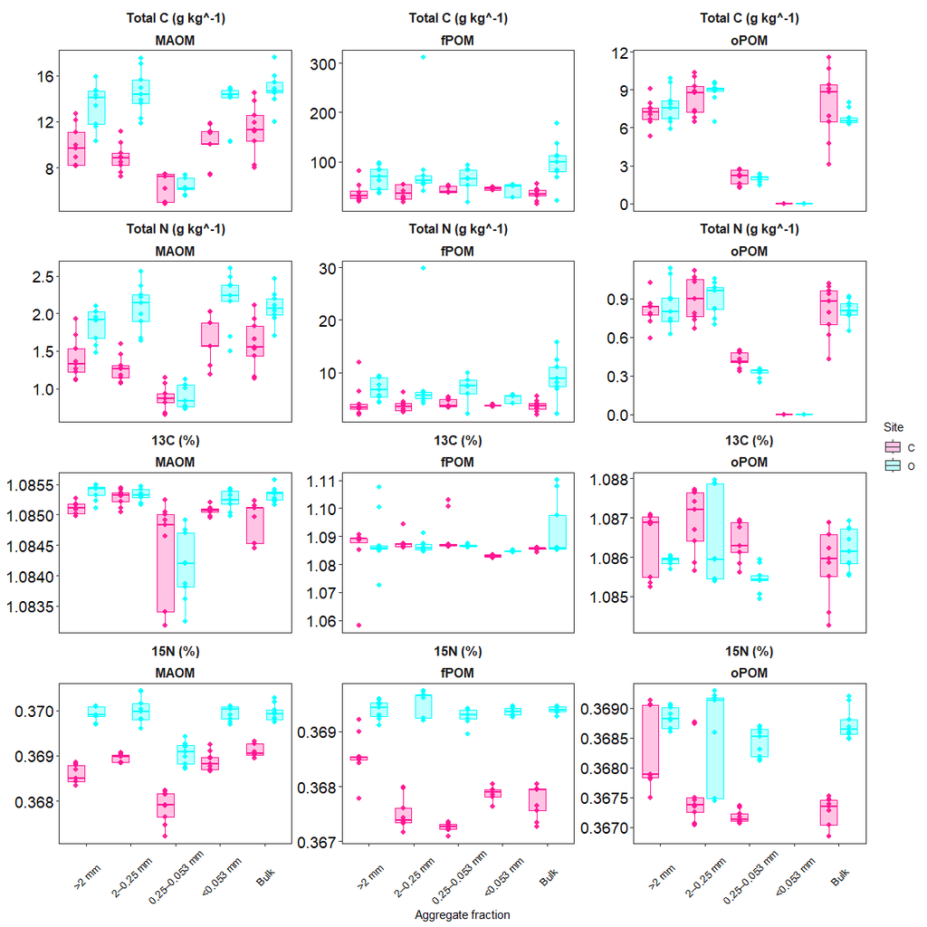

##### Metagenome analysis

**click to open**

##### Overall heatmap

**click to open**

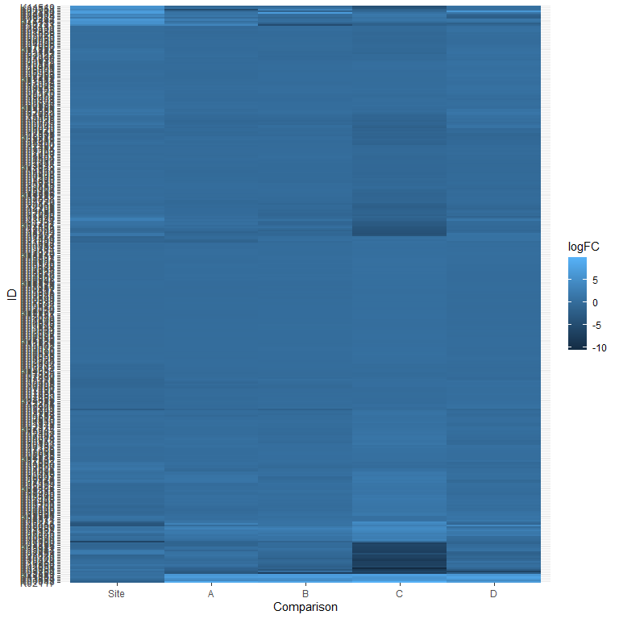

##### Volcano plots show small differences in Site (Organic vs Conventional), and when looking at individual aggregates the 0.053-0.25 mm shows large differences compared with all other aggregate sizes.

**click to open**

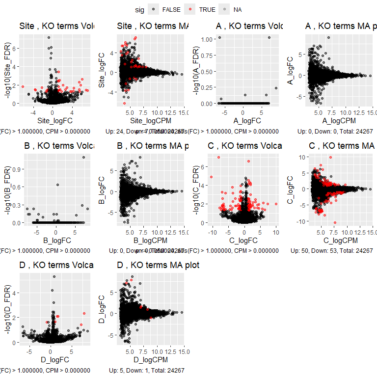

##### Two types of analysis showing what genes are significantly important to the comparison. Site is comparing the conventional and organicly managed plots.Note all aggregates are being compared to the Bulk soil (pre fractionated).

**click to open**

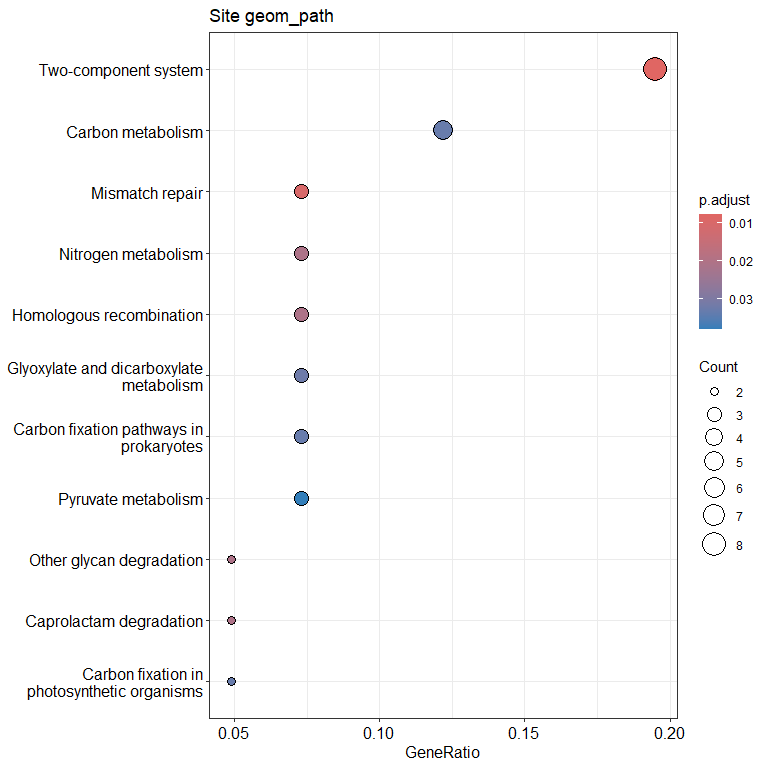

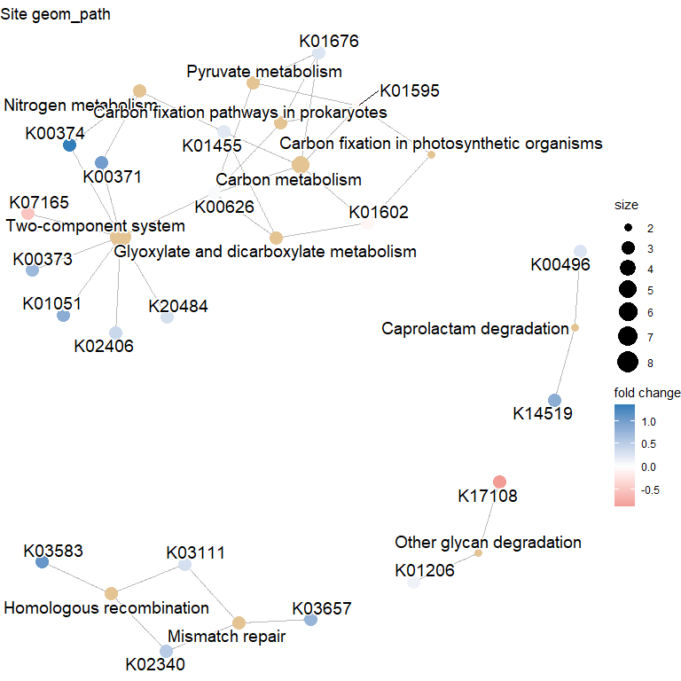

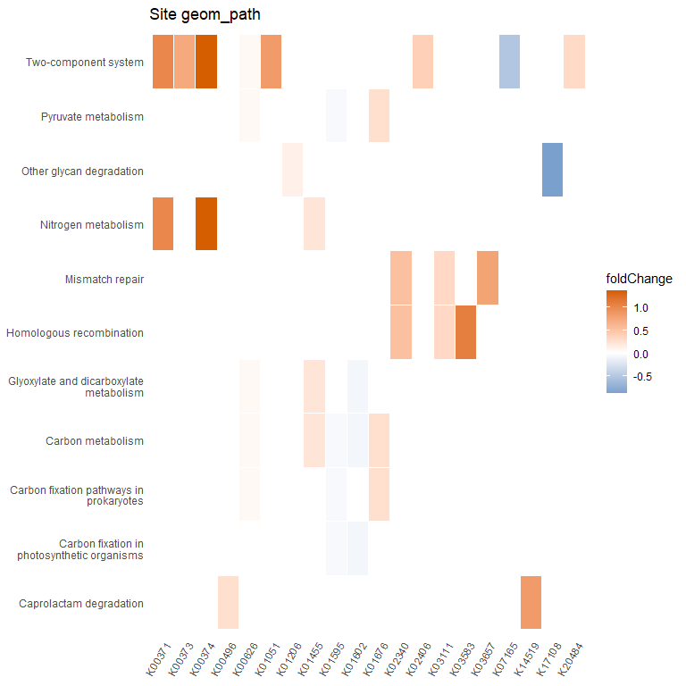

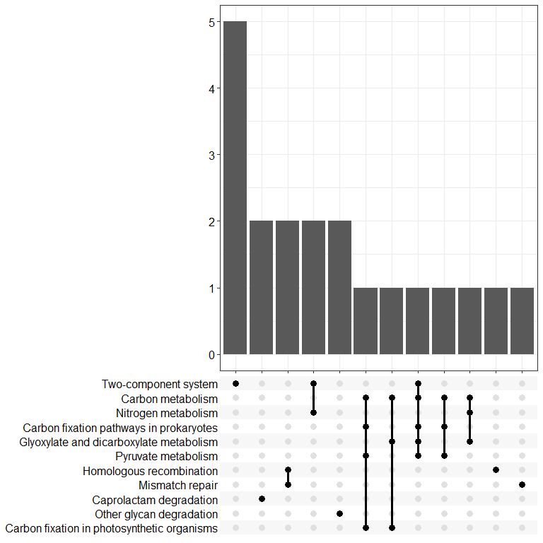

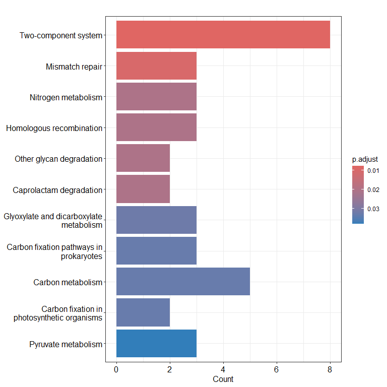

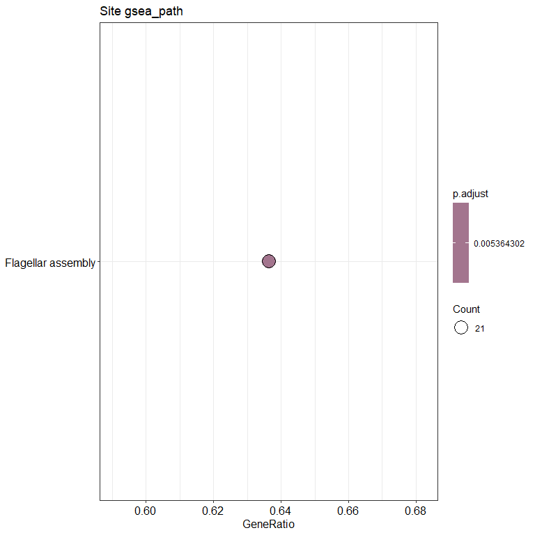

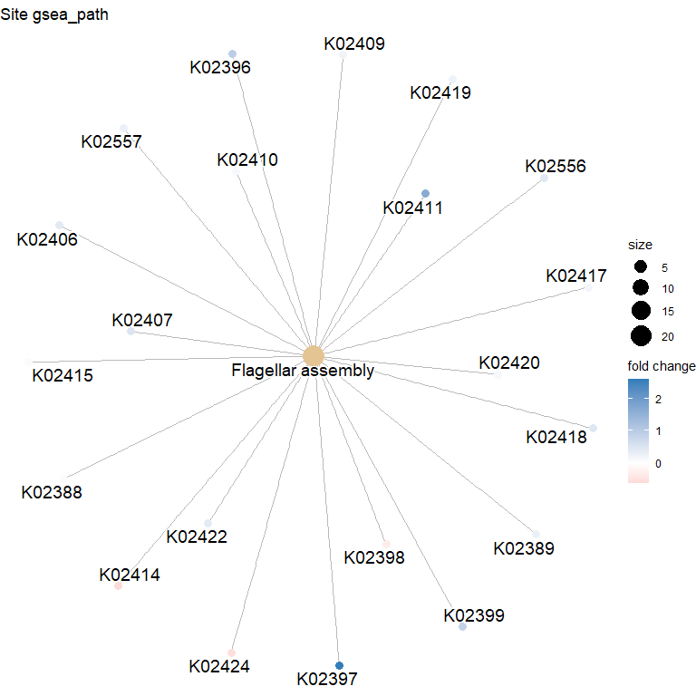

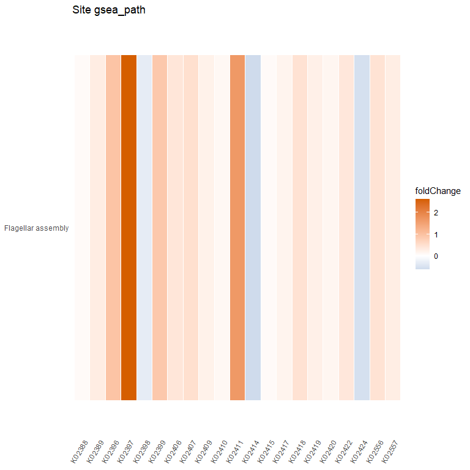

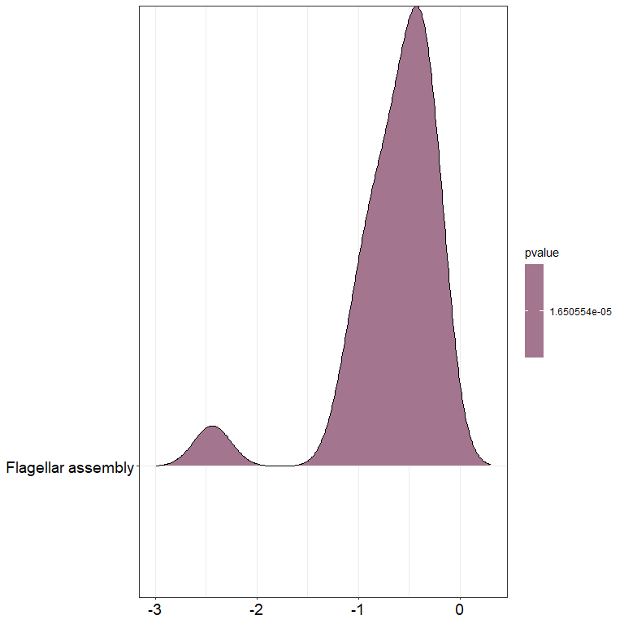

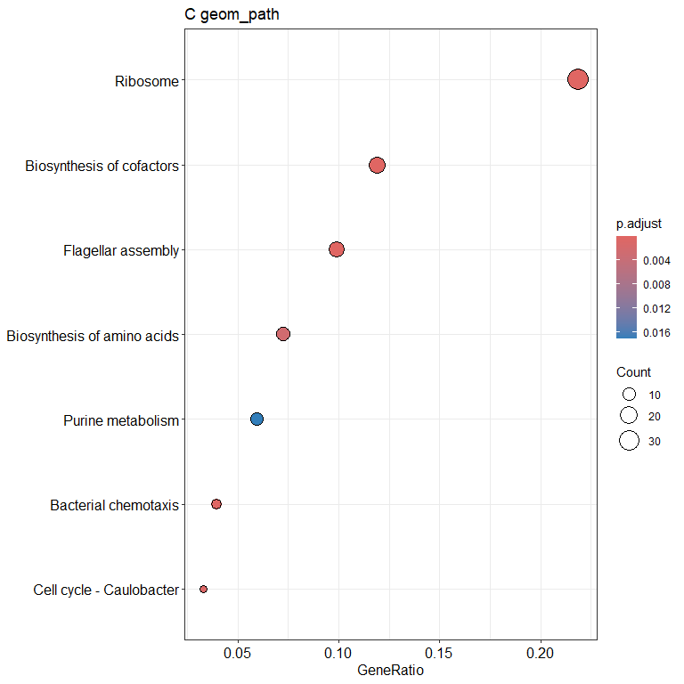

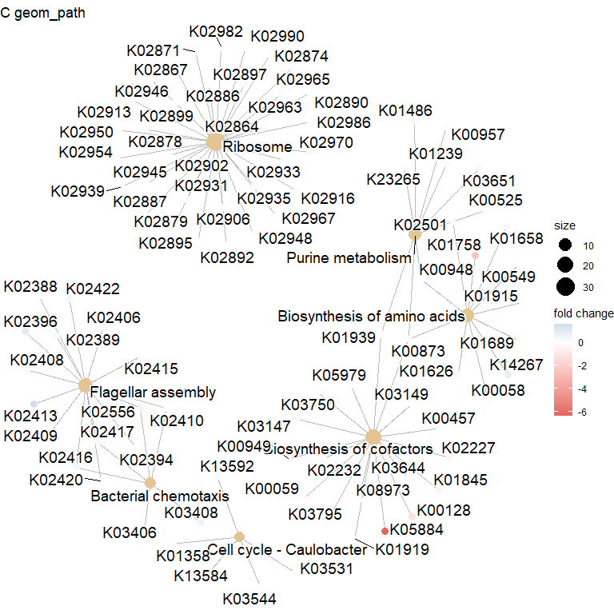

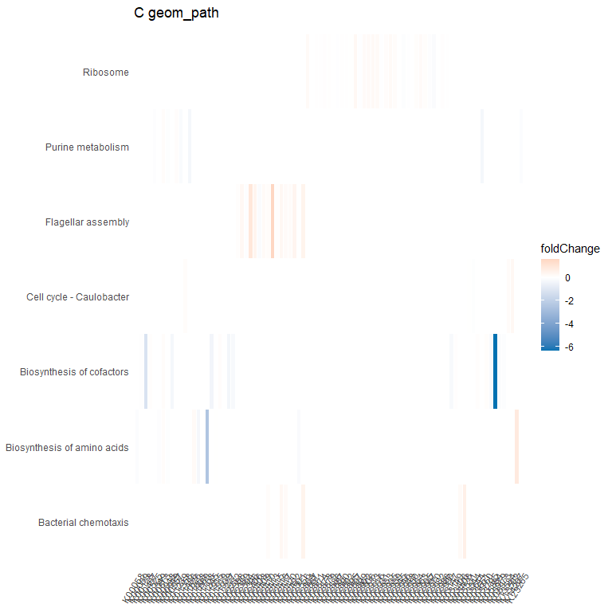

[15 more figures not shown]

##### Dendrogram with heat map— too small to read

**click to open**

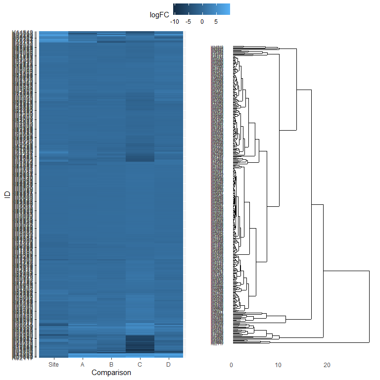

##### Metab analysis

**click to open**

##### Overall heatmap

**click to open**

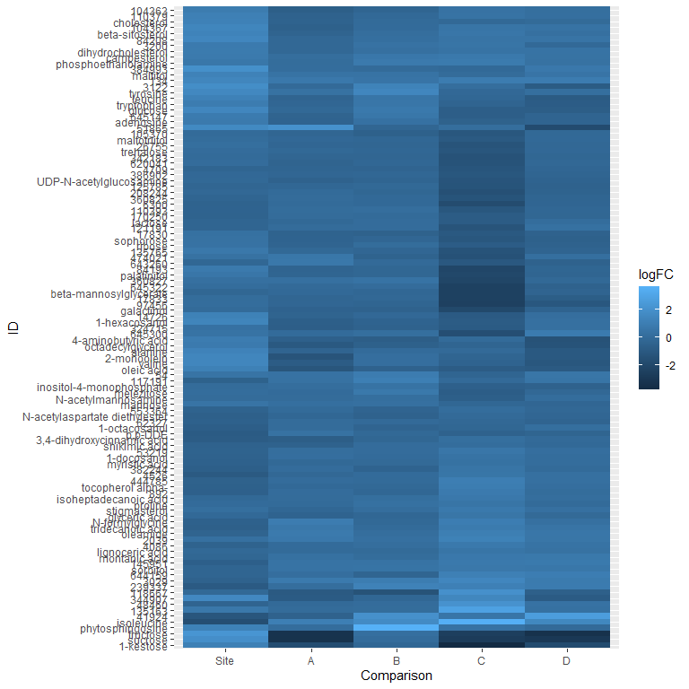

##### Volcano plots show small differences in Site (Organic vs Conventional), and when looking at individual aggregates the 0.053-0.25 mm shows large differences compared with all other aggregate sizes.

**click to open**

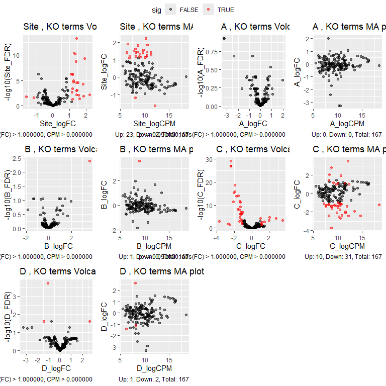

##### Two types of analysis showing what genes are significantly important to the comparison. Site is comparing the conventional and organicly managed plots.Note all aggregates are being compared to the Bulk soil (pre fractionated).

**click to open**

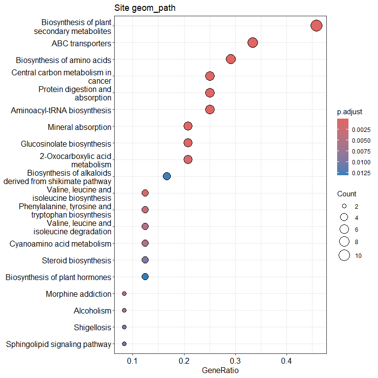

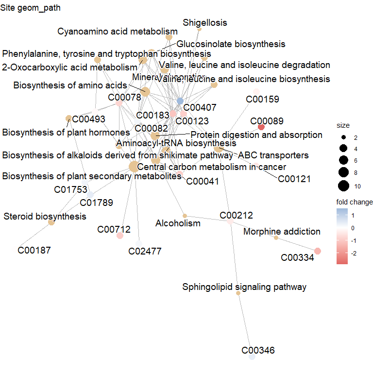

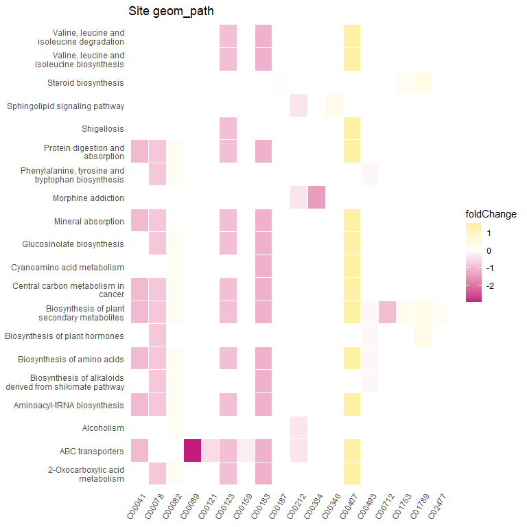

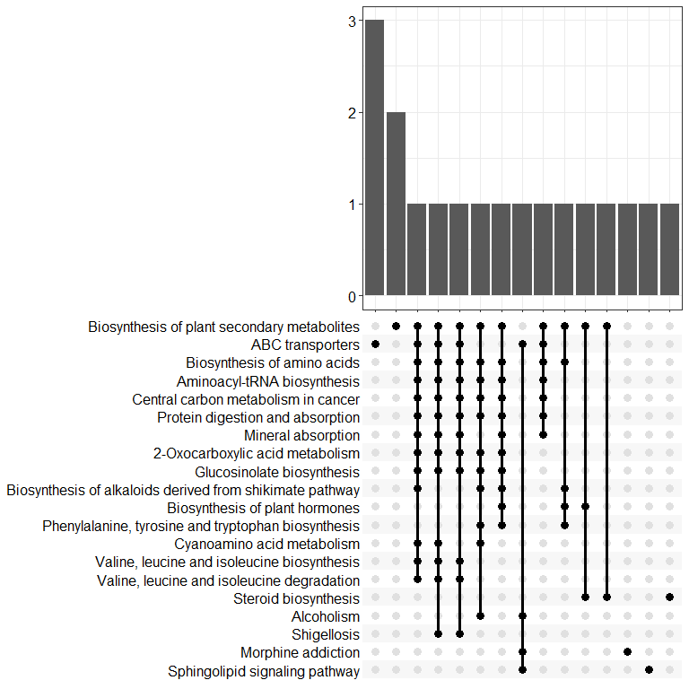

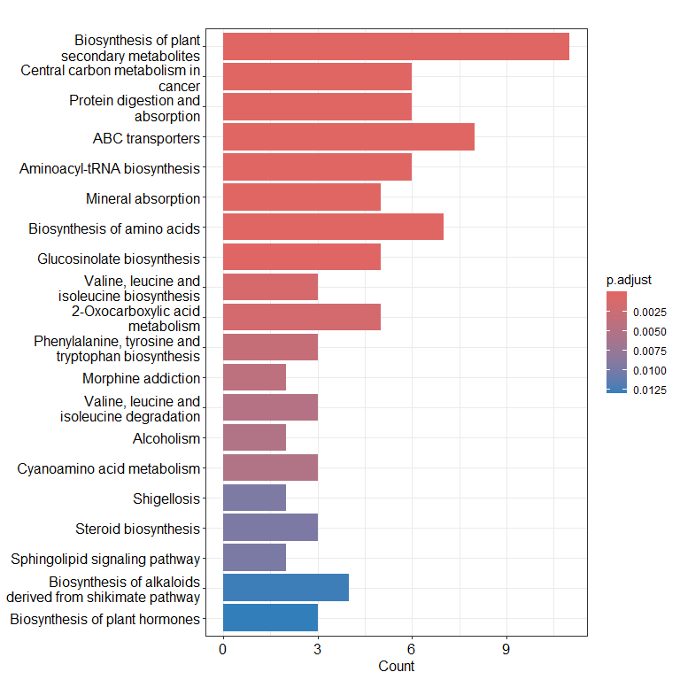

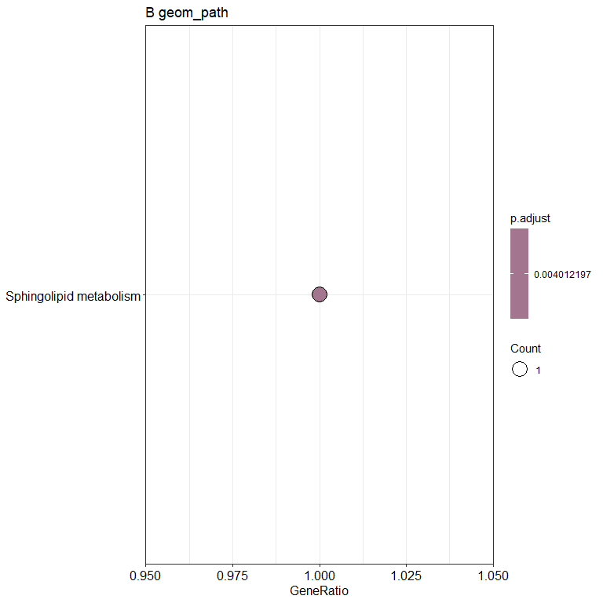

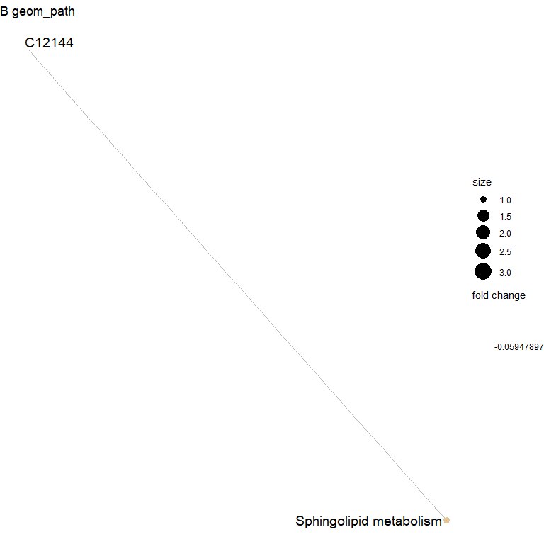

[figure not shown]

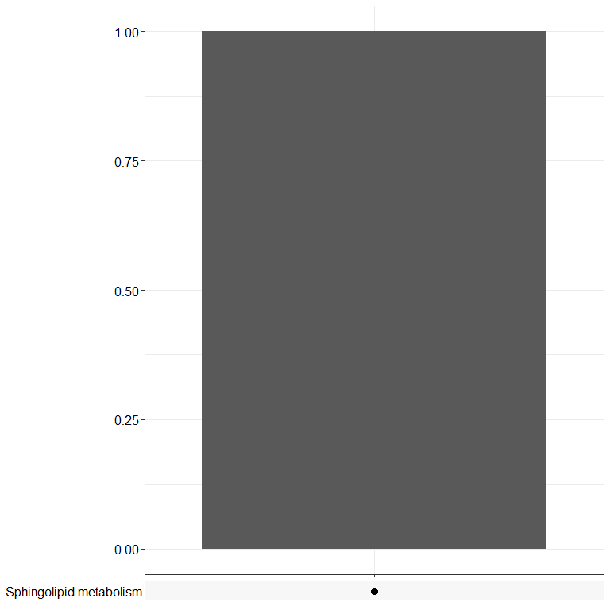

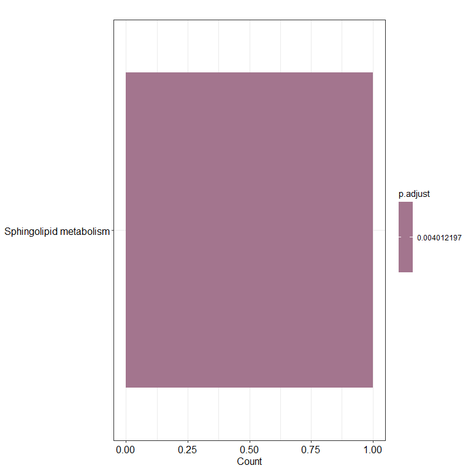

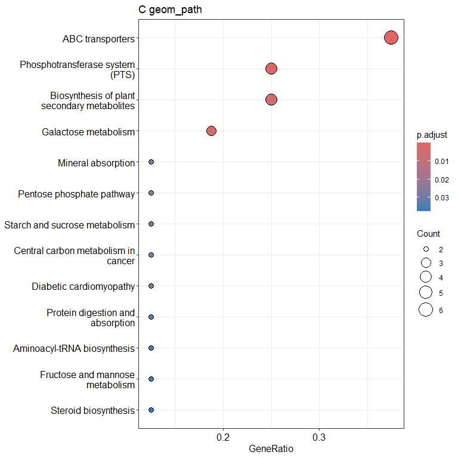

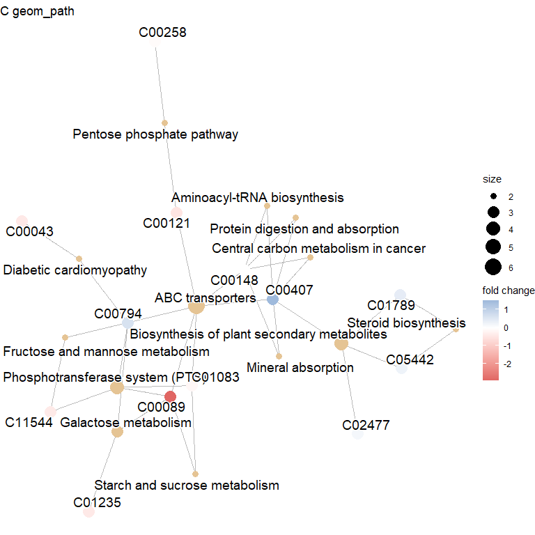

[8 more figures not shown]

##### Dendrogram with heat map— too small to read

**click to open**

[figure not shown]

# Year 2 (2025)

**click to open**

## Soil description

**click to open**

##### The soils were sieved through an 8 mm mesh and stored at -80°C until aggregate fractionation. Each sample underwent two rounds of fractionation. In the first round, soils were sieved, and the resulting aggregates were dried to assess physical properties. Dried aggregates were archived for potential future use. The second round involved sieving without drying, processing only two samples at a time to maintain soil moisture. Soil moisture was adjusted to approximately 68% water holding capacity, determined for each aggregate class from the first sieve.

##### Following this, subsamples were processed as follows: some soils were stored in 1.7 mL tubes at -80°C for extra DNA extractions and metabolomics, 2 g of soil was incubated with ^18O-labeled H₂O to assess carbon use efficiency (CUE), and two 5 g subsamples were used to determine microbial biomass carbon (C) and nitrogen (N) via chloroform fumigation. After the CUE incubation, gas samples were taken from the headspace to measure respiration rates. DNA was then extracted from the soils to analyze ^18O incorporation into DNA during the 24-hour incubation. About 1 microgram of DNA was sent for metagenome analysis, bulk aggregates were sent for soil property assesment, and freeze dried soils were sent in for metabolomic analysis. FDA (cuvets) and POXC (microplate) were also measured using colormetric assays. Enzyme activities were measured via MUF and MC fluorometric microplate assays. OM fractions were also seperated into fPOM/oPOM/MAOM and will be sent for 13C and 15N analysis.

# Session Info

**Session Info**

Date run: 2025-11-25